# Introduction to R

## What is R?

R is an open source programming language for statistical computing. It is one of the current standards for data science. You may freely download and install R on your own computer, but you will likely find it most convenient to use Moravian’s server for this course.

Moravian provides access to R through your browser using a Jupyterhub server. This also provides a convenient environment for working with R.

To access Jupyterhub and R, go to sage.moravian.edu, then log in using your Moravian Gmail credentials.

## Layout of an R Notebook

When you first login to sage.moravian.edu you are presented with the file listing for your personal server. This is where new notebooks will be created and where we can upload data sets. To get started, locate the “New” button on the right side of the screen. Click it, then select “R”. This should open a new tab in your browser with a new notebook for us to work in.

## Setting up for a project

Note, for this section I’ve created a video with the same content. You can watch that video, just read what’s here, or both.

If you want to run R commands, you type them into an empty cell, then hit `Shift-Enter`. Let’s try `1+1`

```r
1+1
```

```
[1] 2
```

Nice job R!

Before we get started doing something more interesting, we should load a library with several utilities that will be useful to us. The library is called `tidyverse`. You will want to load this every time you start working in R.

```r
library(tidyverse)
```

It is normal to see some warnings after loading this library.

Finally, let’s give our document a nice name. Look at the top of the screen, just to the right of the Jupyterhub logo. At the moment my notebook is called “Untitled”. Click the word “Untitled” and you can give it a name. Let’s call it “First R Experience”.

ok, so that’s what you will want to do every time you start a new project: 1. Login to sage.moravian.edu 2. Choose New, then R. 3. Give your document a useful name. 4. Run `library(tidyverse)’ in the first cell.

## Some basic computations

We can store values into variables for later reference. To do that we use the characters `<-’. See how that looks like an arrow? Here I store a number into a variable.

```r
myVariable <- 7
```

It even looks like the 7 is moving into `myVariable`. Now we can use that variable in computations

```r
myVariable +3
```

```
[1] 10
```

## Importing a dataset

But what if we want to do some statistics with R?

Most data sets will be given to us in an external data file which will need to import, then use R commands to analyze.

We will use a data set with some made-up health data. Here is the link: Patient_Data.csv

If your data set is available to download (as this one is) then you can have R load it directly from the URL using the command `read_csv(" ")`. We need to paste the URL into the space between the quotes in the command above.

Right click the link above and select “copy link location”. Now we type `patients <- read_csv("`, then paste the URL we’ve copied, then type `")` and run the command with Shift-Enter

The whole thing should look like this”

```r
patients <- read_csv("https://raw.githubusercontent.com/moravian-mspa/MGMT555/master/m2_Intro_to_R/Patient_Data.csv")
```

Note the quotes around the file URL

R has now loaded the data into a **data frame** and placed it into the variable `patients`. Data frames are how R stores tables of data. We can now refer to this one using the name `patients`.

We can always see what a data set looks like with the following command which displays the first few rows of the data set.

```r
head(patients)
```

```
# A tibble: 6 × 7
  `ID Number` Gender Marital.Status   Age Weight Total.Cholesterol Systolic.Bl…¹
  <chr>       <chr>  <chr>          <dbl>  <dbl>             <dbl>         <dbl>
1 001         F      D                 28     99               192           110
2 002         F      S                 19    102               191           123
3 003         F      S                 19    104               184           117
4 004         F      S                 21    108               189           138
5 005         F      S                 28    109               186           123
6 006         F      W                 40    113               194           138
# … with abbreviated variable name ¹Systolic.Blood.Press
```

I see each row represents a patient and each column represents some data about the patient Most of the column titles are fairly self explanatory. We can see summary statistics easily enough:

```r
summary(patients)
```

```
  ID Number            Gender          Marital.Status          Age
 Length:100         Length:100         Length:100         Min.   :18.00
 Class :character   Class :character   Class :character   1st Qu.:28.75
 Mode  :character   Mode  :character   Mode  :character   Median :38.00
                                                          Mean   :39.22
                                                          3rd Qu.:51.00
                                                          Max.   :79.00
     Weight      Total.Cholesterol Systolic.Blood.Press
 Min.   : 99.0   Min.   :180.0     Min.   :107.0
 1st Qu.:135.8   1st Qu.:198.0     1st Qu.:120.8
 Median :170.0   Median :217.5     Median :131.0
 Mean   :167.0   Mean   :219.3     Mean   :129.7
 3rd Qu.:195.0   3rd Qu.:233.2     3rd Qu.:138.0
 Max.   :261.0   Max.   :294.0     Max.   :152.0
```

If we want a summary of just the age column we can reference that with this code:

```r
summary(patients$Age)
```

```
   Min. 1st Qu.  Median    Mean 3rd Qu.    Max.
  18.00   28.75   38.00   39.22   51.00   79.00
```

The dollar sign after the data frame’s name is there to specify that we want to work with just one column.

We can find the standard deviation of the weight column

```r
sd(patients$Weight)
```

```
[1] 36.34249
```

How about a scatterplot?

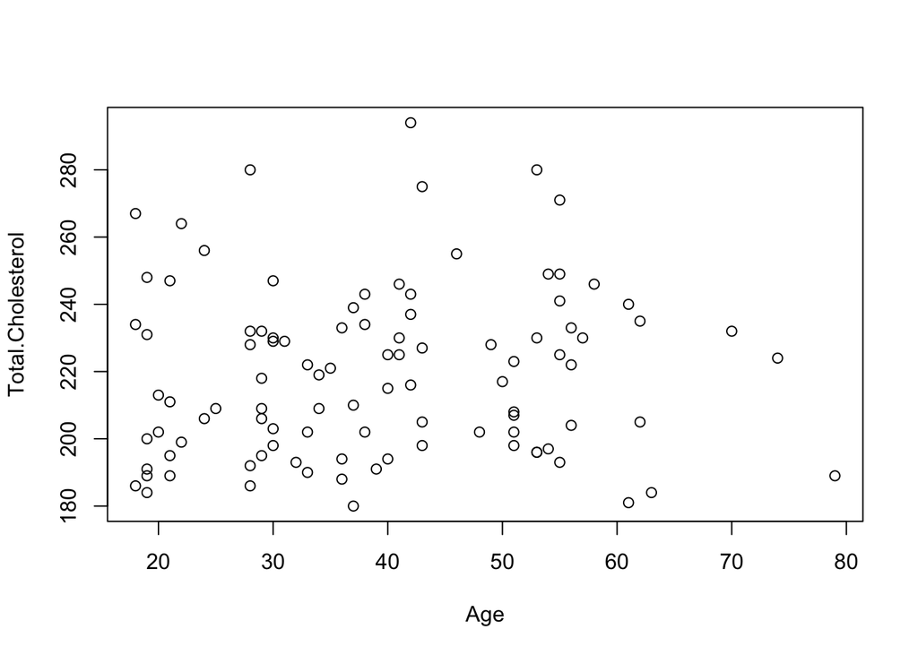

```r
plot(Total.Cholesterol ~ Age, data=patients)
```

And even a confidence interval for the mean age. How easy is that?

```r
t.test(patients$Age)
```

```
    One Sample t-test

data:  patients$Age
t = 27.296, df = 99, p-value < 2.2e-16
alternative hypothesis: true mean is not equal to 0
95 percent confidence interval:
 36.36896 42.07104
sample estimates:
mean of x
    39.22
```

Do you see where the confidence interval is in the output above?

That was so much fun let’s make sure we don’t lose our work. Your work is auto saved, but we can manually save just before we close it by clicking the save icon.

The easiest way to hand in work you’ve done in these notebooks is to download them as html. Click File, “Download As”, then choose HTML. This will download an html file to your computer which you can then submit to Canvas.

## Your Turn

Open up a new `R` notebook for yourself, name it “My Second R Experience”, then load the `tidyverse` library.

Now load the patient data into this new notebook for yourself. Do you remember the command I used above?

1. Find the mean systolic blood pressure for the sample.
2. Find the standard deviation of systolic blood pressure. (Which command did I use above?)
3. Make a scatter plot of age vs systolic blood pressure. (Find the command I used above.)

## Make use of your resources!

Over the course of the semester, we will continue to learn new things to do in R. I will always provide the necessary code (or at the very least sample code) for you to use. Since R is open sourced, you can also always search online for additional help and resources.

https://cran.r-project.org/doc/manuals/R-intro.pdf

**General Help Tip**: Ever wonder what a command does or what arguments you can add to a command? Just type `?` followed by the command name and a help window will pop up. And as always, the internet is your friend! Feel free to use outside resources to help you with the code.